# Bellabeat Case Study

The project lead has asked me to uncover trends within fitness tracker usage, and apply those trends to the marketing of a specific bellabeat product.

Bellabeat sells several items, but the leaf stands out as their flagship product. The Leaf tracks activity, sleep, and stress, and our dataset contains information on activity and sleep, so this analysis begins there.

## dataset quality

Our data is from 2016, which is 8 years out of date. Certain metrics like VeryActiveMinutes are now deprecated. The data also has a relatively small sample size, which makes it less ideal. However, fitness and usage trends in the data are likely still relevant.

# Data prep

```python
import pandas as pd
import numpy as np
import os
from pathlib import Path
import matplotlib
import matplotlib.pyplot as plt
# import seaborn as sns
import patchworklib as pw
from plotnine import ggplot, aes, geom_point, labs, geom_histogram, facet_wrap
```

```python
DATA_PATH=  Path.cwd() / "Fitabase Data 4.12.16-5.12.16"

data=[(pd.read_csv(DATA_PATH/ file), file) for file in os.listdir(DATA_PATH)]

os.listdir(DATA_PATH)
```

```
['minuteIntensitiesWide_merged.csv',
 'dailyActivity_merged.csv',
 'sleepDay_merged.csv',
 'heartrate_seconds_merged.csv',
 'minuteIntensitiesNarrow_merged.csv',
 'minuteMETsNarrow_merged.csv',
 'hourlySteps_merged.csv',
 'hourlyIntensities_merged.csv',
 'dailyCalories_merged.csv',
 'hourlyCalories_merged.csv',
 'minuteSleep_merged.csv',
 'minuteCaloriesNarrow_merged.csv',
 'dailySteps_merged.csv',
 'minuteCaloriesWide_merged.csv',
 'minuteStepsNarrow_merged.csv',
 'minuteStepsWide_merged.csv',
 'weightLogInfo_merged.csv',
 'dailyIntensities_merged.csv']
```

```python
# minuteIntensitiesWide = data[0][0]
dailyActivity = data[1][0]
sleepDay = data[2][0]
heartrate_seconds = data[3][0]
minuteIntensitiesNarrow = data[4][0]
minuteMETsNarrow = data[5][0]
hourlySteps = data[6][0]
hourlyIntensities = data[7][0]
dailyCalories = data[8][0]
hourlyCalories = data[9][0]
minuteSleep = data[10][0]
minuteCaloriesNarrow = data[11][0]
dailySteps = data[12][0]
# minuteCaloriesWide = data[13][0]
minuteStepsNarrow = data[14][0]
# minuteStepsWide = data[15][0]
weightLogInfo = data[16][0]
dailyIntensities = data[17][0]
```

```python
[(file, len(df["Id"].unique())) for df, file in data]
```

```
[('minuteIntensitiesWide_merged.csv', 33),
 ('dailyActivity_merged.csv', 33),
 ('sleepDay_merged.csv', 24),
 ('heartrate_seconds_merged.csv', 14),
 ('minuteIntensitiesNarrow_merged.csv', 33),
 ('minuteMETsNarrow_merged.csv', 33),
 ('hourlySteps_merged.csv', 33),
 ('hourlyIntensities_merged.csv', 33),
 ('dailyCalories_merged.csv', 33),
 ('hourlyCalories_merged.csv', 33),
 ('minuteSleep_merged.csv', 24),
 ('minuteCaloriesNarrow_merged.csv', 33),
 ('dailySteps_merged.csv', 33),
 ('minuteCaloriesWide_merged.csv', 33),
 ('minuteStepsNarrow_merged.csv', 33),
 ('minuteStepsWide_merged.csv', 33),
 ('weightLogInfo_merged.csv', 8),
 ('dailyIntensities_merged.csv', 33)]
```

Check for duplicates

```python
list(enumerate([(df.duplicated().sum(),file) for df, file in data]))
```

```
[(0, (0, 'minuteIntensitiesWide_merged.csv')),
 (1, (0, 'dailyActivity_merged.csv')),
 (2, (3, 'sleepDay_merged.csv')),
 (3, (0, 'heartrate_seconds_merged.csv')),
 (4, (0, 'minuteIntensitiesNarrow_merged.csv')),
 (5, (0, 'minuteMETsNarrow_merged.csv')),
 (6, (0, 'hourlySteps_merged.csv')),
 (7, (0, 'hourlyIntensities_merged.csv')),
 (8, (0, 'dailyCalories_merged.csv')),
 (9, (0, 'hourlyCalories_merged.csv')),
 (10, (543, 'minuteSleep_merged.csv')),
 (11, (0, 'minuteCaloriesNarrow_merged.csv')),
 (12, (0, 'dailySteps_merged.csv')),
 (13, (0, 'minuteCaloriesWide_merged.csv')),
 (14, (0, 'minuteStepsNarrow_merged.csv')),
 (15, (0, 'minuteStepsWide_merged.csv')),
 (16, (0, 'weightLogInfo_merged.csv')),
 (17, (0, 'dailyIntensities_merged.csv'))]
```

```python
# fix duplicate rows
sleepDay.drop_duplicates(inplace=True)
minuteSleep.drop_duplicates(inplace=True)
```

find any nulls

```python
[(df.columns[df.isna().any()].tolist(), file) for df, file in data]
```

```
[([], 'minuteIntensitiesWide_merged.csv'),
 ([], 'dailyActivity_merged.csv'),
 ([], 'sleepDay_merged.csv'),
 ([], 'heartrate_seconds_merged.csv'),
 ([], 'minuteIntensitiesNarrow_merged.csv'),
 ([], 'minuteMETsNarrow_merged.csv'),
 ([], 'hourlySteps_merged.csv'),
 ([], 'hourlyIntensities_merged.csv'),
 ([], 'dailyCalories_merged.csv'),
 ([], 'hourlyCalories_merged.csv'),
 ([], 'minuteSleep_merged.csv'),
 ([], 'minuteCaloriesNarrow_merged.csv'),
 ([], 'dailySteps_merged.csv'),
 ([], 'minuteCaloriesWide_merged.csv'),
 ([], 'minuteStepsNarrow_merged.csv'),
 ([], 'minuteStepsWide_merged.csv'),
 (['Fat'], 'weightLogInfo_merged.csv'),
 ([], 'dailyIntensities_merged.csv')]
```

We aren't using the weightLogInfo anyway.

Standardize datetime columns

```python
dailyActivity["datetime"] = pd.to_datetime(dailyActivity["ActivityDate"], format="%m/%d/%Y")
sleepDay["datetime"] = pd.to_datetime(sleepDay["SleepDay"], format="%m/%d/%Y %I:%M:%S %p")


# the following are redundant with dailyActivity
# dailyCalories["datetime"] = pd.to_datetime(dailyCalories["ActivityDay"], format="%m/%d/%Y")
# dailySteps["datetime"] = pd.to_datetime(dailySteps["ActivityDay"], format="%m/%d/%Y")
# dailyIntensities["datetime"] = pd.to_datetime(dailyIntensities["ActivityDay"], format="%m/%d/%Y")


hourlyCalories["datetime"] = pd.to_datetime(hourlyCalories["ActivityHour"], format="%m/%d/%Y %I:%M:%S %p")
hourlySteps["datetime"] = pd.to_datetime(hourlySteps["ActivityHour"], format="%m/%d/%Y %I:%M:%S %p")
hourlyIntensities["datetime"] = pd.to_datetime(hourlyIntensities["ActivityHour"], format="%m/%d/%Y %I:%M:%S %p")


minuteIntensitiesNarrow["datetime"] = pd.to_datetime(minuteIntensitiesNarrow["ActivityMinute"], format="%m/%d/%Y %I:%M:%S %p")
minuteMETsNarrow["datetime"] = pd.to_datetime(minuteMETsNarrow["ActivityMinute"], format="%m/%d/%Y %I:%M:%S %p")
minuteCaloriesNarrow["datetime"] = pd.to_datetime(minuteCaloriesNarrow["ActivityMinute"], format="%m/%d/%Y %I:%M:%S %p")
minuteStepsNarrow["datetime"] = pd.to_datetime(minuteStepsNarrow["ActivityMinute"], format="%m/%d/%Y %I:%M:%S %p")
minuteSleep["datetime"] = pd.to_datetime(minuteSleep["date"], format="%m/%d/%Y %I:%M:%S %p")


weightLogInfo["datetime"] = pd.to_datetime(weightLogInfo["Date"], format="%m/%d/%Y %I:%M:%S %p")
heartrate_seconds["datetime"] = pd.to_datetime(heartrate_seconds["Time"], format="%m/%d/%Y %I:%M:%S %p")
```

```python
daily = [dailyActivity,sleepDay]
hourly = [hourlyCalories,hourlySteps,hourlyIntensities]
minute = [minuteIntensitiesNarrow,minuteMETsNarrow,minuteCaloriesNarrow,minuteStepsNarrow,minuteSleep]
```

```python
heartrate_seconds.rename(columns={"Value":"heartrate"}, inplace=True)
minuteSleep.rename(columns={"value":"sleep"}, inplace=True)
```

# Analysis

## Activity

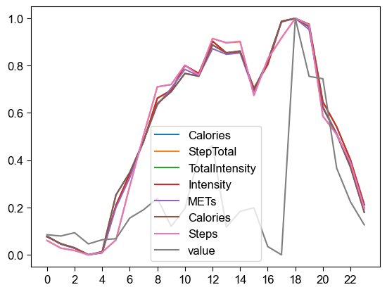

```python
from sklearn.preprocessing import MinMaxScaler

# get hourly dfs
hourlyActivity= [(df.groupby(df["datetime"].dt.hour)[df.columns[2]].mean()) for df in hourly + minute]

# combine hourly dfs
df= pd.concat(hourlyActivity, axis=1)

fig, ax = plt.subplots()

# Set the number of ticks on the x-axis
ax.set_xticks(np.arange(0, 24, 2))
# normalize
scaler = MinMaxScaler()
pd.DataFrame(scaler.fit_transform(df), columns=df.columns).plot(ax=ax)
```

All measures except sleep, when normalized, follow almost exactly the same path, peaking at 12pm-2pm and again at 5pm-7pm. It appears that people are getting their exercise in the afternoon, especially at lunch and directly after work. Conversely, they are relatively inactive in the morning and evening.

Bellabeat can send their users notifications during or before peak activity to increase motivation and engagement. They can also encourage appropriate activities during low-activity times like the early morning and late evening, such as morning routines like yoga or meditation, or bedtime relaxation. If Bellabeat has these features, they could advertise that they are sensitive to users energy levels throughout the day.

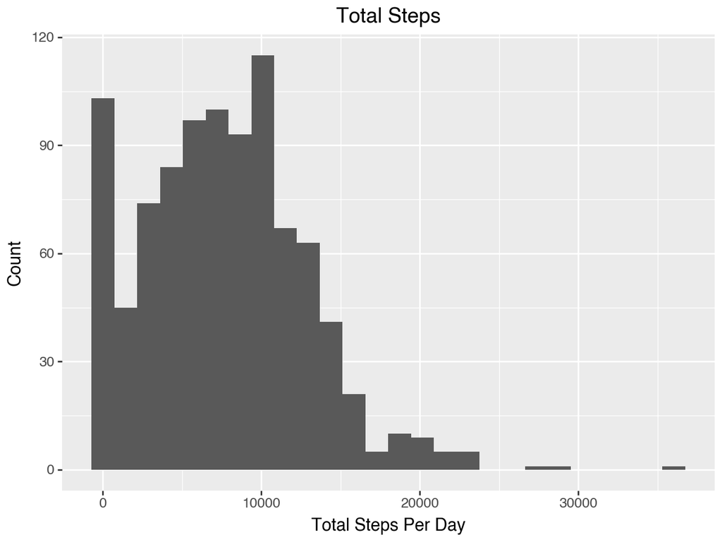

```python
# fig, ax= plt.subplots()
# dailyActivity["TotalSteps"].plot(kind="hist", ax=ax)

ggplot(dailyActivity, aes(x='TotalSteps')) + geom_histogram() + labs(title='Total Steps', x='Total Steps Per Day', y='Count')
```

There are a large number of days with zero steps. This could be because they aren't using their tracker. Bellabeat could send a prompt asking if they are using their tracker and reminding them of the benefits of being aware of how many steps they are taking.

With these features, Bellabeat can market that it takes an individual and health oriented perspective on activity, customizing suggestions for each user.

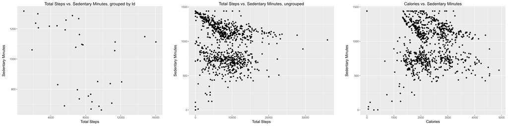

```python
gpbyID = dailyActivity.groupby("Id", as_index=False)[["TotalSteps", "SedentaryMinutes"]].mean()
plot1 = (ggplot(gpbyID, aes(x='TotalSteps', y='SedentaryMinutes')) +
        geom_point() +
        labs(title='Total Steps vs. Sedentary Minutes, grouped by Id',
             x='Total Steps',
             y='Sedentary Minutes'))

plot2 = (ggplot(dailyActivity, aes(x='TotalSteps', y='SedentaryMinutes')) +
        geom_point() +
        labs(title='Total Steps vs. Sedentary Minutes, ungrouped',
             x='Total Steps',
             y='Sedentary Minutes'))
plot3 = (ggplot(dailyActivity, aes(x='Calories', y='SedentaryMinutes')) +
        geom_point() +
        labs(title='Calories vs. Sedentary Minutes',
             x='Calories',
             y='Sedentary Minutes'))

(pw.load_ggplot(plot1) | pw.load_ggplot(plot2) | pw.load_ggplot(plot3))
```

We see two groups in these graphs: those with more than a 1000 sedentary minutes (16 hours) and those with less than that.

Those in the more sedentary category likely have desk jobs, while those in the other group do not. If the category split was due to athleticism or having an excersise routine, lower sedentary minutes would correlate more strongly with total steps. If it were due to health, the segmentation would be more graded. If it were a weekend/weekday split, day of week faceting would reveal the trend.

Bellabeat can segment their campaigns based on activity class.

- Active users may be interested in tracking caloric burn and seeing how their daily activity contributes to overall fitness. They may also be reminded that just because they are less sedentary doesn't mean they are necessarily burning more calories or taking more steps.
- More sedentary users could use movement reminders after prolonged sitting.

If they offer segmented advice, Bellabeat can advertise that they personalize their results based on activity level and other metrics.

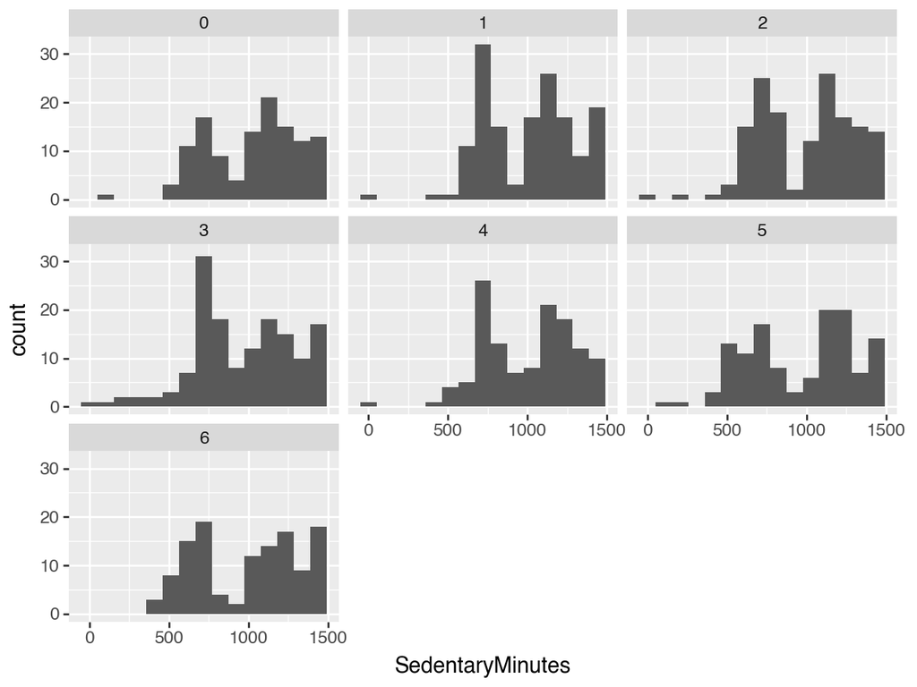

```python
ggplot(dailyActivity, aes(x="SedentaryMinutes")) + geom_histogram() + facet_wrap("DOW")
```

The two groups of sedentary minutes persist over the week, indicating there is no weekday/weekend split.

```python
# daily = [dailyActivity,sleepDay]

dailyDf = dailyActivity.merge(sleepDay, on=["Id", "datetime"])
```

# Sleep

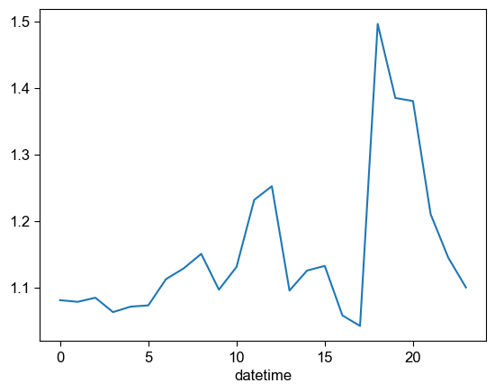

```python
minuteSleep.groupby(minuteSleep["datetime"].dt.hour)["sleep"].mean().plot(x="datetime", y="sleep")
```

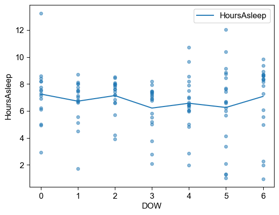

```python
fig, ax= plt.subplots()

# ax.set_ylim([0, 600])
sleepDay["DOW"] = sleepDay["datetime"].dt.day_of_week
sleepDay["HoursAsleep"] = sleepDay["TotalMinutesAsleep"] / 60
sleepDayDOW = sleepDay.groupby(["DOW", "Id"], as_index=False)[["HoursAsleep", "DOW"]].mean()



for day, df in sleepDayDOW.groupby("DOW"):
    df.plot(kind="scatter", x="DOW", y="HoursAsleep", ax=ax, alpha=0.5)
(sleepDayDOW.groupby("DOW")[["HoursAsleep"]]
 .mean()
 .plot(ax=ax, y=["HoursAsleep"])
)
```

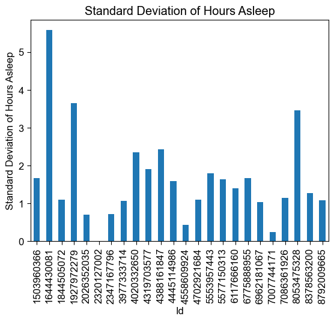

```python
variance = sleepDay.groupby("Id")["HoursAsleep"].std().plot(kind="bar",
                                                            x="Id",
                                                            y="HoursAsleep",
                                                            title="Standard Deviation of Hours Asleep",
                                                            ylabel="Standard Deviation of Hours Asleep")
```

Because it tracks sleep habits, Bellabeat's Leaf can encourage users with higher sleep variability to become more consistent. We can market the product based on this benefit.

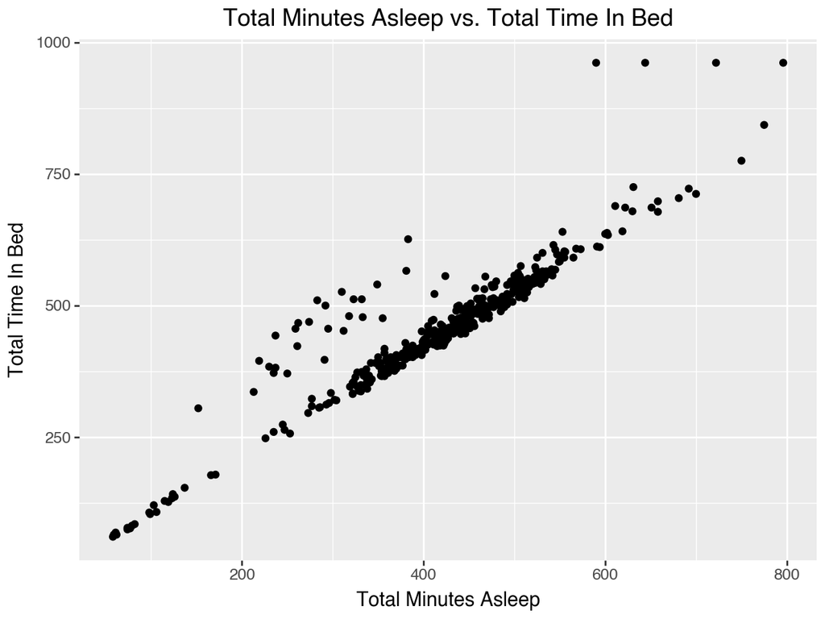

```python
(ggplot(sleepDay, aes(x='TotalMinutesAsleep', y='TotalTimeInBed')) +
  geom_point() +
    labs(title='Total Minutes Asleep vs. Total Time In Bed', x='Total Minutes Asleep', y='Total Time In Bed'))
```

In general, sleep time matches time in bed. However, on a subset of nights, people spend more time in bed than they do asleep, meaning that they are likely having trouble sleeping. Bellabeat can market to this subset of people, showing that Bellabeat's sleep tracker can monitor sleep quality and suggest ways to improve it (less caffeine and alcohol for example) when it isn't great. It can also help identify users with chronic sleep problems.